# vouchered reference DNA pool: investigating false positives

The goal of the vouchered reference DNA pool was to check on false positives that arise from the lab/analysis workflow. This is a subset of the data included in the full reference DNA pool, but many of those tissue samples could easily have been exposed to contamination from other fishes at seafood markets.

Here, my goals are to understand the various sources of contamination in the vouchered pool.

I want to rule out contamination from: 1. lab sources 2. extraction blanks and PCRs 3. errors in the GenBank and BOLD databases 4. poor resolution at a particular locus

These data are derived from the analyses in `01-taxonomy-filter-BLAST-hits.Rmd` and `09-integr-taxonomic-levels-within-loci.Rmd`.

## Load data

```r
# load libraries
library(tidyverse)
library(stringi)
library(readxl)

# read in data - the cleaned, filtered feature table with dissimilar replicates removed and metadata

# integrated taxonomy/feature table
loc_integr <- read_rds("../data/reference_mock_communities_within_locus_integration.rds")

# meta data for group and type assignments
meta <- read_csv("../data/jan_sample_list.csv")
# list of species in the reference mock community
reference_spp <- readxl::read_xlsx("../data/full_reference_spp_database_info.xlsx") %>%
  select(2:4, 6:11)
```

```
* `` -> ...12
```

```r
# voucher reference pools
VRP <- reference_spp %>%
  mutate(control = "positive") %>%
  filter(Vouchered == "yes")

# SODM-filtered taxa (output list from prior analysis)
sodm_filtered_taxa <- read_csv("../data/exploring_false_positives_sodm_06082020.csv")
```

For going back to accession numbers…

```r
feature_df <- readRDS("../data/feature_df_no_eDNA.rds")
```

Remove the loci that didn’t pass dissimilarity filtering because of a lack of reads: teleo, crust2, 16Sfish

```r
VRP.loc <- loc_integr %>%
  filter(stri_detect(sample, regex = "VRP")) %>% # just the vouchered reference DNA pool samples
  filter(!locus %in% c("teleo", "crust2", "16Sfish")) %>% # remove loci with too few reads
  select(sample, locus, species, genus, family, taxon, taxonomic_level) %>%
  unique()
```

How many are inaccurate?

Get a list of false positives to explain using extraction blanks, negative controls, and biogeography

```r
# species-level false positives
species_level_false_positives <- VRP %>%
  full_join(., VRP.loc, by = c("species" ,"genus","family")) %>%
  filter(taxonomic_level == c("species")) %>% # need to match the taxonomic level to the appropriate degree of specificity from the joining step
  mutate(`vouchered taxa` = ifelse(is.na(control), "false", "true")) %>%
  select(locus, `vouchered taxa`, species) %>%
  unique() %>%
  filter(`vouchered taxa` == "false") %>% # probably want to add back in the read counts
  left_join(., loc_integr, by = c("locus", "species")) %>%
  filter(str_detect(sample, "VRP"))

# genus-level
genus_level_false_positives <- VRP %>%
  full_join(., VRP.loc, by = c("genus","family")) %>%
  filter(taxonomic_level == c("species", "genus")) %>%# for genus-level matches, any better taxonomic-level (species) should be included
  mutate(`vouchered taxa` = ifelse(is.na(control), "false", "true")) %>%
  select(locus, `vouchered taxa`, genus) %>%
  unique() %>%
  filter(`vouchered taxa` == "false") %>% # probably want to add back in the read counts
  left_join(., loc_integr, by = c("locus", "genus")) %>%
  filter(str_detect(sample, "VRP"))
```

```
longer object length is not a multiple of shorter object length
```

```r
# family-level
family_level_false_positives <- VRP %>%
  full_join(., VRP.loc, by = c("family")) %>%  # correct reference families (not necessarily correct genus/species)
  filter(taxonomic_level == c("species", "genus", "family")) %>% # for family-level matches, any better taxonomic-level should be included
  mutate(`vouchered taxa` = ifelse(is.na(control), "false", "true")) %>%
  select(locus, `vouchered taxa`, family) %>%
  unique() %>%
  filter(`vouchered taxa` == "false") %>% # probably want to add back in the read counts
  left_join(., loc_integr, by = c("locus", "family")) %>%
  filter(str_detect(sample, "VRP"))
```

```
longer object length is not a multiple of shorter object length
```

## Cleaning up the false positives

### Filtering based on presence of those false positives in the lab

Read in the data manually filled out

```r
# read in a file that was manually updated with potential sources of lab contamination
false_positives <- read_csv("../data/voucher_pool_false_positives.csv")
# take a look at how many were in the lab
lab_contaminants <- false_positives %>%
  filter(present_in_lab == 1)

# I can remove these from the "false positives" because they might be legitimately detected.
```

Trying to get the bottom of sources of contamination. 1. lab (other species floating around that we know of) 2. poor resolution at that locus (should be locus-specific?) OR no reference seq for the correct taxa at that locus. 3. other??

```r
# from the original list of false positives, how many can be accounted for easily?
false_positives_summarized <- false_positives %>%
  filter(present_in_lab == 0) %>% # remove those taxa that we know to be sources of contamination
  filter(species != "Kudoa_sp.") %>% # remove the fish parasite
  group_by(family, genus, species) %>% # how many taxa show up in multiple loci?
  add_tally(name = "n_loci") %>%
  arrange(desc(n_loci)) %>%
  select(-locus, -max_reads) %>%
  unique()# how many of these were also removed by SODM?

# how many belong to the same family as one or more reference taxa?
remaining_FP <- false_positives_summarized %>%
  left_join(., reference_spp, by = "family") %>%
  ungroup() %>%
  select(species.x) %>%
  unique() %>%
  rename(species = species.x)

family_reference_matches <- false_positives_summarized %>%
  left_join(., reference_spp, by = "family") %>%
  mutate(source = ifelse(!is.na(species.y), "family_match_ref_taxa", NA)) %>%
  filter(!is.na(source)) %>%
  ungroup() %>%
  select(taxon, source) %>%
  unique()
```

At the species-level, how many of the false positives are in the correct genus of either a reference species or known lab contaminant?

43 of 70 entries are in the same family as one of the reference species.

What is the mean number of reads per reference taxon? And are these far outside the expected read counts?

The Stephanolepis is far and away the most baffling. Is it only detected by COI genes, 16S, and 12S.

```r
# need the taxonomy df for the read counts
features_w_taxonomy <- readRDS("../data/feature_df_no_eDNA_metazoa_only.rds")
tax_df_spp_98 <- readRDS("../data/uncollapsed_taxonomy_spp_98.rds")

# merge those
merged_df <- features_w_taxonomy %>%
  left_join(tax_df_spp_98)
# just the VRP reference taxa
vrp_taxa_counts <- VRP %>%
  left_join(., merged_df) %>%
  filter(str_detect(sample, "VRP")) %>%
  group_by(locus, sample, species) %>%
  summarise(total_count = sum(count)) %>%
  ungroup()
vrp_mean_cts <- vrp_taxa_counts %>%
  group_by(locus) %>%
  summarise(mean = mean(total_count)) %>%
  arrange(mean)
```

Maybe another way to deal with the false positives is to remove entries that are < 1% of the mean number of reads?

```r
vrp_counts_df <- VRP %>%
  full_join(., VRP.loc, by = c("species" ,"genus","family")) %>%
  filter(taxonomic_level == c("species")) %>% # need to match the taxonomic level to the appropriate degree of specificity from the joining step
  select(locus, sample, species, genus, family, control, taxon, taxonomic_level) %>%
    anti_join(., lab_contaminants, by = c("locus", "species", "genus", "family")) %>%
  group_by(locus, sample, control) %>% # how many false positives per replicate?
  tally() %>%
  ungroup() %>%
  group_by(locus, control) %>%
  mutate(mean_count = mean(n)) %>%
  mutate(min_count = min(n)) %>%
  mutate(max_count = max(n))
```

## Extraction blanks and negative controls

What about the false positives that are also showing up in the extraction blanks and negative controls?

```r
blanks_negs <- feature_df %>% # I should swap this df to be the one with just metazoa anyway...
  left_join(., tax_df_spp_98) %>%
  filter(str_detect(sample, "EXB") | str_detect(sample, "NEG"))
# species?
negs <- blanks_negs %>%
  filter(!is.na(taxon)) %>%
  semi_join(., false_positives, by = "taxon") %>%
  select(locus, species, genus, family, taxon) %>%
  unique() %>%
  mutate(source = "negative_controls")
```

```r
known_contam <- lab_contaminants %>%
  select(locus, family, species, genus, taxon) %>%
  mutate(source = "lab_contamination") %>%
  full_join(., negs)
#these are the false positives accounted for by potential lab contamination and blanks
known_false_pos <- false_positives %>%
  full_join(., known_contam) %>%
  filter(!is.na(vouchered.taxa) & !is.na(source))
# are some of the contamination patterns consistent across loci?
general_contam <- known_contam %>%
  select(-locus, -taxon) %>% # remove locus
  unique()
```

```r
vrp_counts_df <- VRP %>%
  full_join(., VRP.loc, by = c("species" ,"genus","family")) %>%
  filter(taxonomic_level == c("species")) %>% # need to match the taxonomic level to the appropriate degree of specificity from the joining step
  select(locus, sample, species, genus, family, control, taxon, taxonomic_level) %>%
    anti_join(., general_contam, by = c("species", "genus", "family")) %>%
  group_by(locus, sample, control) %>% # how many false positives per replicate?
  add_tally() %>%
  ungroup() %>%
  group_by(locus, control) %>%
  mutate(mean_count = mean(n)) %>%
  mutate(min_count = min(n)) %>%
  mutate(max_count = max(n)) %>%
  select(locus, control, mean_count, min_count, max_count) %>%
  unique() %>%
  mutate(`vouchered taxa` = ifelse(is.na(control), "false", "true")) %>%
  ungroup() %>%
  select(locus, `vouchered taxa`, mean_count, min_count, max_count) %>%
  unique()

vrp_counts_df$vouch2 <- factor(vrp_counts_df$`vouchered taxa`, levels = c("true", "false"))

vrp_counts_df2 <- vrp_counts_df %>%
  complete(locus, vouch2) %>% # fill in missing data!
  mutate(mean_count = replace_na(mean_count, 0)) %>%
  group_by(locus) %>%
  mutate(order = sum(mean_count))
```

```r
contaminant_families <- general_contam %>%
  select(family) %>%
  unique() %>%
  anti_join(., VRP)
```

```r
# join the dataframe to the reference species by family
# include all taxonomic levels up to family
# remove the lab/known contaminants - false positives
# calculate the number of true/false positives per replicate
# and then take the mean/min/max numbers across replicates within a locus
vrp_family_df <- VRP %>%
  full_join(., VRP.loc, by = c("family")) %>%
  filter(taxonomic_level %in% c("species", "genus", "family")) %>%
  anti_join(., contaminant_families) %>%
  select(locus, sample, control, family) %>%
  unique() %>%
  group_by(locus, sample, control) %>% # how many false positives per replicate?
  add_tally(name = "tally_per_rep") %>%
  ungroup() %>%
  group_by(locus, control) %>%
  mutate(mean_count = mean(tally_per_rep)) %>%
  mutate(min_count = min(tally_per_rep)) %>%
  mutate(max_count = max(tally_per_rep)) %>%
  select(locus, control, mean_count, min_count, max_count) %>%
  unique() %>%
  mutate(`vouchered taxa` = ifelse(is.na(control), "false", "true")) %>%
  ungroup() %>%
  select(locus, `vouchered taxa`, mean_count, min_count, max_count) %>%
  unique()
# create factor levels for plotting missing categories (bars)
vrp_family_df$vouch2 <- factor(vrp_family_df$`vouchered taxa`, levels = c("true", "false"))

vrp_family_df2 <- vrp_family_df %>%
  complete(locus, vouch2) %>% # fill in missing data!
  mutate(mean_count = replace_na(mean_count, 0)) %>%
  group_by(locus) %>%
  mutate(order = sum(mean_count))
```

Do similarly for genus - first get a list of the genus contaminants

```r
contaminant_genera <- general_contam %>%
  select(genus) %>%
  unique() %>%
  anti_join(., VRP)
```

```r
# join the dataframe to the reference species by genus
# include all taxonomic levels up to family
# remove the lab/known contaminants - false positives
# calculate the number of true/false positives per replicate
# and then take the mean/min/max numbers across replicates within a locus
vrp_genus_df <- VRP %>%
  full_join(., VRP.loc, by = c("genus", "family")) %>%
  filter(taxonomic_level %in% c("species", "genus")) %>%
  anti_join(., contaminant_genera) %>%
  select(locus, sample, control, genus) %>%
  unique() %>%
  group_by(locus, sample, control) %>% # how many false positives per replicate?
  add_tally(name = "tally_per_rep") %>%
  ungroup() %>%
  group_by(locus, control) %>%
  mutate(mean_count = mean(tally_per_rep)) %>%
  mutate(min_count = min(tally_per_rep)) %>%
  mutate(max_count = max(tally_per_rep)) %>%
  select(locus, control, mean_count, min_count, max_count) %>%
  unique() %>%
  mutate(`vouchered taxa` = ifelse(is.na(control), "false", "true")) %>%
  ungroup() %>%
  select(locus, `vouchered taxa`, mean_count, min_count, max_count) %>%
  unique()
# create factor levels for plotting missing categories (bars)
vrp_genus_df$vouch2 <- factor(vrp_genus_df$`vouchered taxa`, levels = c("true", "false"))

vrp_genus_df2 <- vrp_genus_df %>%
  complete(locus, vouch2) %>% # fill in missing data!
  mutate(mean_count = replace_na(mean_count, 0)) %>%
  group_by(locus) %>%
  mutate(order = sum(mean_count))
```

And for consistency, and to make sure everything is accurate, do the same for species

```r
contaminant_species <- general_contam %>%
  select(species) %>%
  unique() %>%
  anti_join(., VRP)
```

```r
# join the dataframe to the reference species by species
# include just species-level taxonomic hits
# remove the lab/known contaminants - false positives
# calculate the number of true/false positives per replicate
# and then take the mean/min/max numbers across replicates within a locus
vrp_spp_df <- VRP %>%
  full_join(., VRP.loc, by = c("species", "genus", "family")) %>%
  filter(taxonomic_level %in% "species") %>%
  anti_join(., contaminant_species) %>%
  select(locus, sample, control, species) %>%
  unique() %>%
  group_by(locus, sample, control) %>% # how many false positives per replicate?
  add_tally(name = "tally_per_rep") %>%
  ungroup() %>%
  group_by(locus, control) %>%
  mutate(mean_count = mean(tally_per_rep)) %>%
  mutate(min_count = min(tally_per_rep)) %>%
  mutate(max_count = max(tally_per_rep)) %>%
  select(locus, control, mean_count, min_count, max_count) %>%
  unique() %>%
  mutate(`vouchered taxa` = ifelse(is.na(control), "false", "true")) %>%
  ungroup() %>%
  select(locus, `vouchered taxa`, mean_count, min_count, max_count) %>%
  unique()
# create factor levels for plotting missing categories (bars)
vrp_spp_df$vouch2 <- factor(vrp_spp_df$`vouchered taxa`, levels = c("true", "false"))

vrp_spp_df2 <- vrp_spp_df %>%
  complete(locus, vouch2) %>% # fill in missing data!
  mutate(mean_count = replace_na(mean_count, 0)) %>%
  group_by(locus) %>%
  mutate(order = sum(mean_count))

# combine all three ranks
spp <- vrp_spp_df2 %>%
  mutate(tax.rank = "species")

gen <- vrp_genus_df2 %>%
  mutate(tax.rank = "genus")

fam <- vrp_family_df2 %>%
  mutate(tax.rank = "family")

vrp_combo_df <- bind_rows(spp, gen, fam)
```

```r
# # reformat the dataframe to make the stacked barplot
stacked_df <- vrp_combo_df %>%
  mutate(fill = ifelse(vouch2 == "false", "false positive", tax.rank)) %>%
  mutate(remove = ifelse(fill == "false positive" & tax.rank %in% c("genus", "family"), "yes", "no")) %>%
  filter(remove == "no")

# change the factor levels
stacked_df$fill <- factor(stacked_df$fill, levels = c("family","genus", "species", "false positive"))
```

## More questions about false positives…

```r
ord_loc <- stacked_df %>%
  select(locus, order)

temp_stack <- stacked_df %>%
  select(locus, mean_count, order, fill)

# add in known lab contamination
lab_contam_df <- known_contam %>%
  select(locus, taxon, source) %>%
    mutate(taxon = ifelse(taxon == "Litopeneaus_vannamei", "Litopeneaus", taxon)) %>%
  unique() %>%
  group_by(locus) %>%
  add_tally(name = "mean_count") %>%
  mutate(fill = "lab taxa") %>%
  select(-taxon, - source)

almost_df <- ord_loc %>%
  left_join(., lab_contam_df) %>%
  unique() %>%
  bind_rows(., temp_stack)
almost_df$fill <- factor(almost_df$fill, levels = c("family", "genus", "species", "lab taxa", "false positive"))
```

2. Which FP (that are not caused by known lab contamination) are shared among loci?

Create a single df that traces as many of the sources as we can…

```r
lab_contam <- known_contam %>%
  select(-locus)
```

The round-up: which FPs can be attributed to which sources?

```r
FP_roundup <- false_positives %>%
  left_join(., family_reference_matches) %>%
  left_join(., lab_contam, by = "taxon") %>%
  mutate(source = ifelse(is.na(source.x), source.y, source.x)) %>%
  select(source, taxon, locus) %>%
  mutate(source = ifelse(source == "negative_controls", "lab_contamination", source)) %>%
  mutate(source = ifelse(taxon == "Kudoa", "specimen_contamination", source)) %>%
  mutate(taxon = ifelse(taxon == "Cololabis_saira", "Cololabis", taxon)) %>%
  unique() %>%
  group_by(locus, source) %>%
  add_tally(name = "n_FP") %>%
  left_join(., false_positives) %>%
  select(source, locus, species, genus, family, taxon)
```

The SODM filtered taxa were already removed, so I can add those back on for the relevant loci:

```r
roundup2 <- FP_roundup %>%
  bind_rows(sodm_filtered_taxa) %>%
  mutate(taxon = ifelse(is.na(species), genus, species)) %>%
  mutate(taxon = ifelse(is.na(genus), family, taxon)) %>%
  mutate(taxon = ifelse(is.na(taxon), "Cololabis_sp.", taxon)) %>%
  select(source, locus, taxon) %>%
  group_by(locus, source) %>%
  add_tally(name = "n_FP") %>%
  select(source, locus, n_FP) %>%
  unique() %>%
  ungroup() %>%
  mutate(source = ifelse(is.na(source), "other", source))

loc_ordered_uniq <- stacked_df %>%
  filter(fill == "genus") %>% # select this arbitrarily to get a single order-set
  select(locus, order)
```

```r
# remake this with the NA loci as well.
almost_df$fill <- as.character(almost_df$fill)
```

## Species-level false positives

```r
# select just the species-level false positives, since those are the ones that will be used for the biogeographic inference (in the feeds)
FP_lab_taxa_w_family_matches <- false_positives %>%
  filter(taxonomic_level == "species") %>%
  mutate(fill = ifelse(present_in_lab == 1, "lab taxa (sp)", NA)) %>%
  select(locus, species, fill) %>%
  left_join(., family_reference_matches, by = c("species" = "taxon")) %>% # add in putative lab contamination
  mutate(fill = ifelse(is.na(fill) & source == "family_match_ref_taxa", "lab taxa (genus or family)", fill))
```

```r
# summarize species-level occupancy model removals
sodm_spp_for_joining <- sodm_filtered_taxa %>%
  select(locus, species) %>%
  filter(!is.na(species)) %>%
  mutate(fill = "occupancy model")

false_positives_accounting <- FP_lab_taxa_w_family_matches %>%
  select(-source) %>%
  mutate(fill = ifelse(is.na(fill), "other", fill)) %>%
  bind_rows(., sodm_spp_for_joining) %>%
  group_by(locus, fill) %>%
  tally(name = "sp_count")


combined_voucher_FP_df <- almost_df %>%
  filter(fill %in% c("species", "genus", "family")) %>%
  select(-order) %>%
  rename(sp_count = mean_count) %>%
  bind_rows(., false_positives_accounting) %>%
  left_join(loc_ordered_uniq) %>%
  ungroup() %>%
  mutate(fill = ifelse(fill == "species", "species (voucher)", fill)) %>%
    mutate(fill = ifelse(fill == "genus", "genus (voucher)", fill)) %>%
    mutate(fill = ifelse(fill == "family", "family (voucher)", fill))
# set the factor levels for the fill order
combined_voucher_FP_df$fill <- factor(combined_voucher_FP_df$fill, levels = c("species (voucher)", "genus (voucher)", "family (voucher)", "lab taxa (sp)", "lab taxa (genus or family)",  "occupancy model", "other"))
```

keep the species info:

```r
FP_spp_w_taxon_names <- false_positives %>%
  filter(taxonomic_level == "species") %>%
  mutate(fill = ifelse(present_in_lab == 1, "lab taxa (sp)", NA)) %>%
  left_join(., family_reference_matches, by = c("species" = "taxon")) %>% # add in putative lab contamination
  mutate(fill = ifelse(is.na(fill) & source == "family_match_ref_taxa", "lab taxa (genus or family)", fill)) %>%
  select(locus, species, fill)
```

```r
# add in the genus and family level SODM taxa to the species
sodm_spp <- sodm_filtered_taxa %>%
  mutate(fill = source) %>%
  mutate(taxonomic_level = ifelse(is.na(species), "genus", "species")) %>%
    mutate(taxonomic_level = ifelse(is.na(genus), "family", taxonomic_level)) %>%
  filter(taxonomic_level == "species") %>%
  select(locus, species, fill)
```

There are 5 false positives at the species level that cannot be accounted for by lab contamination etc. Uranoscopus_japonicus (Japanese stargazer) = indo-Pacific distribution Thalassoma_quinquevittatum (Pinkface wrasse) = Pacific Muraenesox_cinereus (Daggertooth pike conger) = indo-Pacific to Red Sea Gavialiceps_taiwanensis (pike conger) = indo-Pacific Chimaera_phantasma (Silver chimaera, ghost shark) = W. Pacific

## Gains from data decontamination

Here we want to compare the decontaminated and not-decontaminated data to determine what the gains were from the species occupancy modeling and dissimilarity steps.

```r
# read in the data for the vouchered reference samples without the decontamination steps
no_decontam <- read_rds("../data/within_locus_integration_no_decontamination.rds") %>%
  filter(str_detect(sample, "VRP"))

# how many false positives are present in the non-decontaminated data?
no_decontam_false_pos <- no_decontam %>%
  filter(!locus %in% c("teleo", "crust2", "16Sfish")) %>% # ignore the 3 loci with too few reads
  select(sample, locus, species, genus, family, taxon, taxonomic_level) %>%
  unique() %>%
  filter(taxonomic_level == "species") %>%
  full_join(reference_spp) %>%
  left_join(lab_contam) %>%
  select(locus, species, source, Vouchered) %>%
  mutate(source = ifelse(Vouchered == "no", "lab_contamination", source)) %>%
  filter(is.na(Vouchered)) %>%
  group_by(locus) %>%
  unique()
# designate whether the taxa identified in the vouchered reference pool samples was lab contamination
decon_false_pos <- loc_integr %>%
  filter(str_detect(sample, "VRP")) %>% # only vouchered reference pool samples
  filter(!locus %in% c("teleo", "crust2", "16Sfish")) %>% # ignore the 3 loci with too few reads
  select(sample, locus, species, genus, family, taxon, taxonomic_level) %>%
  unique() %>%
  filter(taxonomic_level == "species") %>% # only species-level
  full_join(reference_spp) %>% # which were reference species?
  left_join(lab_contam) %>% # which were lab contamination?
  select(locus, species, source, Vouchered) %>%
  mutate(source = ifelse(Vouchered == "no", "lab_contamination", source)) %>% # if the ref species that were not vouchered are present, then they are lab contamination
  filter(is.na(Vouchered)) %>%
  group_by(locus) %>%
  unique()
# how many false positives were removed by decontamination?
anti_join(no_decontam_false_pos, decon_false_pos)
```

| locus | species | source | Vouchered |
| --- | --- | --- | --- |
| 18Sn4 | Callorhinchus_milii | NA | NA |
| 18Sn4 | Gonorynchus_greyi | NA | NA |
| aquaF2 | Pinjalo_pinjalo | NA | NA |
| cep | Balistoides_conspicillum | NA | NA |
| cep | Calotomus_spinidens | NA | NA |
| fishminiA | Ostorhinchus_sealei | NA | NA |
| mifish | Gavialiceps_taeniola | NA | NA |
| mifish | Lates_calcarifer | NA | NA |
| mifish | Fundulus_grandis | NA | NA |
| mifish | Zenion_japonicum | NA | NA |

[output cut: 6 more lines]

There are 16 false positives (species) that were removed by the decontamination process… both sodm and dissimilarity.

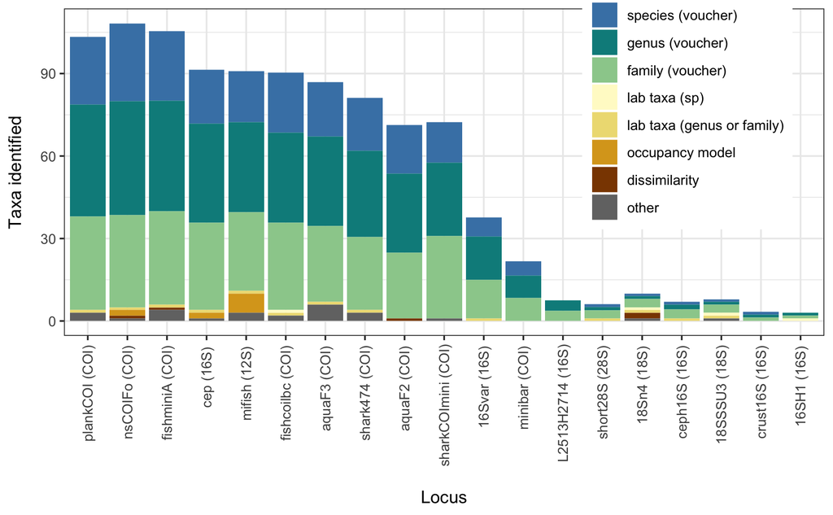

```r
# add the taxa that were removed by dissimilarity
# subtract the sodm to get the dissimilarity benefit.
dissimilarity_FPs <- anti_join(no_decontam_false_pos, decon_false_pos) %>%
  left_join(., sodm_spp_for_joining) %>%
  mutate(fill = ifelse(is.na(fill), "dissimilarity", fill)) %>% # if it wasn't removed by the sodm, it was the   dissimilarity filter
  filter(fill == "dissimilarity") %>%
  select(-Vouchered)
# add in SODM and tally
false_positives_accounting2 <- FP_lab_taxa_w_family_matches %>%
  select(-source) %>%
  mutate(fill = ifelse(is.na(fill), "other", fill)) %>%
  bind_rows(., sodm_spp_for_joining) %>%
  bind_rows(., dissimilarity_FPs) %>%
  group_by(locus, fill) %>%
  tally(name = "sp_count")


combined_voucher_FP_df <- almost_df %>%
  filter(fill %in% c("species", "genus", "family")) %>%
  select(-order) %>%
  rename(sp_count = mean_count) %>%
  bind_rows(., false_positives_accounting2) %>%
  left_join(loc_ordered_uniq) %>%
  ungroup() %>%
  mutate(fill = ifelse(fill == "species", "species (voucher)", fill)) %>%
    mutate(fill = ifelse(fill == "genus", "genus (voucher)", fill)) %>%
    mutate(fill = ifelse(fill == "family", "family (voucher)", fill)) %>%
   mutate(gene = ifelse(locus %in% c("fishminiA", "nsCOIFo", "shark474", "aquaF3", "aquaF2", "plankCOI", "fishcoilbc", "sharkCOImini", "minibar", "crust2"), "COI", "16S")) %>%
  mutate(gene = ifelse(locus %in% c("mifish", "teleo"), "12S", gene)) %>%
    mutate(gene = ifelse(str_detect(locus, "18S"), "18S", gene)) %>%
      mutate(gene = ifelse(str_detect(locus, "28S"), "28S", gene)) %>%
  mutate(gene = paste0("(",gene,")")) %>%
  unite(loc.gene, locus, gene, sep = " ", remove = F)
# set the factor levels for the fill order
combined_voucher_FP_df$fill <- factor(combined_voucher_FP_df$fill, levels = c("species (voucher)", "genus (voucher)", "family (voucher)", "lab taxa (sp)", "lab taxa (genus or family)",  "occupancy model", "dissimilarity",  "other"))

# now set the colors for those levels
my_pal <- c("steelblue", "darkcyan", "darkseagreen3")
fp_combo_pal <- c(my_pal,
                  "lemonchiffon1", "lightgoldenrod",  "goldenrod", "darkorange4", "gray45")

# plot that up
  dodge_plot3 <- combined_voucher_FP_df %>%
  ggplot(aes(x = reorder(loc.gene,-order), y = sp_count, fill = fill)) +
  geom_bar(stat = "identity", position = "stack") +
  theme_bw() +
  xlab("Locus") +
  ylab("Taxa identified") +
  scale_fill_manual(values = c(fp_combo_pal))

dodge_plot3 +
  theme(
    axis.text.x = element_text(angle = 90, hjust = 0.95, vjust = 0.5),
    axis.title.x = element_text(margin = margin(t = 15)),
    axis.title.y = element_text(margin = margin(r = 10)),
    legend.position=c(0.82,0.7),
    legend.title = element_blank()
    )

ggsave("pdf_outputs/vouchered_pool_false_positives_stackplot.pdf", height = 6, width = 8)
```

### Remaining false positives, per locus

[output not shown]